# Лабораторная работа №1. Модель экспоненциального роста

Численное решение ОДУ в Julia

Автор

принадлежность

Амина Накова

Российский университет дружбы народов

Аннотация

В отчёте рассматривается модель экспоненциального роста du/dt = αu. Уравнение решается численно методом Tsit5() на языке Julia с использованием пакетов DifferentialEquations.jl и Plots.jl. Проведено параметрическое исследование для различных значений α.

Полученные результаты совпадают с аналитическим решением u(t) = u₀e^(αt).

Ключевые слова

математическое моделирование, Julia, ОДУ, экспоненциальный рост, DrWatson

# 1 Введение

## 1.1 Актуальность

Модель экспоненциального роста — одна из базовых моделей математического моделирования. Она описывает процессы, в которых скорость изменения величины пропорциональна её текущему значению: рост популяции в неограниченной среде, сложный процент, начальная фаза эпидемий, цепные реакции.

## 1.2 Цель работы

Изучить модель экспоненциального роста `du/dt = αu`, реализовать её численное решение в Julia, исследовать поведение решения при разных значениях параметра α.

## 1.3 Задачи

1. Реализовать численное решение ОДУ `du/dt = αu` в Julia.
2. Построить график решения и сравнить с аналитическим.
3. Провести параметрическое сканирование по α.
4. Исследовать зависимость времени удвоения `t₂ = ln(2)/α` от скорости роста.
5. Оформить код в литературном стиле с использованием `Literate.jl`.
6. Организовать проект средствами `DrWatson.jl`.

## 1.4 Объект и предмет исследования

**Объект:** обыкновенное дифференциальное уравнение первого порядка. **Предмет:** численные методы решения ОДУ и их поведение в зависимости от параметров модели.

## 1.5 Методы исследования

Численное интегрирование методом `Tsit5()` (адаптивный метод Рунге-Кутты 5-го порядка). Визуализация результатов средствами `Plots.jl`. Организация проекта — `DrWatson.jl`. Литературное программирование — `Literate.jl`.

# 2 Теоретическая часть

Дифференциальное уравнение экспоненциального роста:

$$\frac{du}{dt} = \alpha u, \quad u(0) = u_0$$

Здесь: - `u` — текущее значение величины, - `t` — время, - `α` — константа роста (мальтузианский параметр).

Аналитическое решение:

$$u(t) = u_0 e^{\alpha t}$$

Время удвоения (постоянно и не зависит от текущего размера):

$$t_2 = \frac{\ln 2}{\alpha}$$

При `α > 0` наблюдается экспоненциальный рост, при `α < 0` — затухание.

# 3 Материалы и методы

Работа выполнялась на языке **Julia 1.13** с пакетами: - `DifferentialEquations.jl` — численное решение ОДУ, - `Plots.jl` — визуализация, - `DataFrames.jl` — таблицы результатов, - `DrWatson.jl` — организация проекта, - `Literate.jl` — литературное программирование, - `BenchmarkTools.jl` — бенчмаркинг.

Проект организован через `DrWatson.jl` с типовой структурой: `scripts/`, `notebooks/`, `markdown/`, `data/`, `plots/`.

# 4 Выполнение лабораторной работы

## 4.1 Базовая модель

Реализовано численное решение уравнения `du/dt = αu` с параметрами: - `u₀ = 1.0`, `α = 0.3`, `t ∈ [0, 10]`.

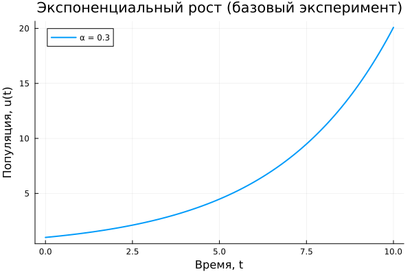

Рисунок 1: Численное решение уравнения du/dt = 0.3·u

Финальная популяция: `u(10) ≈ 20.085`, время удвоения `t₂ ≈ 2.31`.

## 4.2 Параметрическое исследование

Таблица 1: Результаты параметрического сканирования

| α | Финальная популяция | Время удвоения |
| --- | --- | --- |
| 0.1 | 2.718 | 6.931 |
| 0.3 | 20.085 | 2.310 |
| 0.5 | 148.409 | 1.386 |
| 0.8 | 2980.57 | 0.866 |
| 1.0 | 22021.0 | 0.693 |

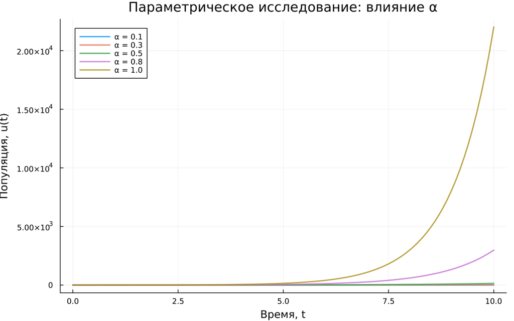

Рисунок 2: Сравнение траекторий при разных α

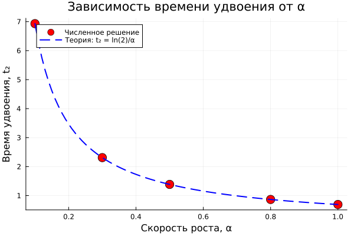

Рисунок 3: Время удвоения vs α

# 5 Результаты

- Численное решение совпадает с аналитическим `u(t) = u₀e^(αt)`.
- Время удвоения `t₂ = ln(2)/α` подтверждено численно для всех α.
- Финальная популяция при `t = 10` для α = 1.0 достигает ≈ 22021.

# 6 Обсуждение результатов

# 7 Заключение

- Цель работы достигнута: модель `du/dt = αu` численно решена.
- Получены все ключевые характеристики: время удвоения, финальная популяция.
- Результаты сохранены средствами `DrWatson` и оформлены в литературном стиле.

# Список литературы

## 8 Приложение А. Листинг программы

Полный код доступен в репозитории: `labs/lab01/project/scripts/01_exponential_growth.jl`.